# Peer Assignment 1- R Markdown

The first chunk of code required to begin the data analysis loads the required .csv file and processes it into a form suitable for analysis. Relevant code is shown below.

```r
data<-read.csv("activity.csv")
```

A quick analysis of the loaded data shows a data.frame consisting of 17568 observation of 3 variables, as produced by the “str” function.

```r
str(data)
```

```
## 'data.frame':    17568 obs. of  3 variables:
##  $ steps   : int  NA NA NA NA NA NA NA NA NA NA ...
##  $ date    : Factor w/ 61 levels "2012-10-01","2012-10-02",..: 1 1 1 1 1 1 1 1 1 1 ...
##  $ interval: int  0 5 10 15 20 25 30 35 40 45 ...
```

To create the histogram and find mean and median by day the plyr package is called, using the function ddply. Here a data.frame is returned, with the sum of the number of steps by day being the output. A histogram of number of steps is created and mean and median number of steps are calculated.

```r
library(plyr)
```

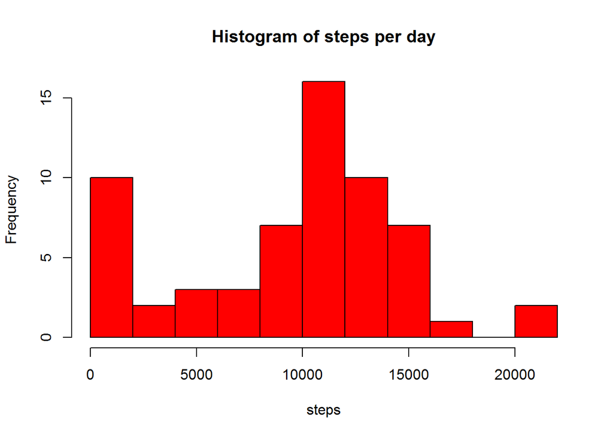

```r
data2<-ddply(data, "date", function(df)sum(df$steps, na.rm=T))
hist(data2$V1, xlab="steps", col="red", main="Histogram of steps per day", breaks=10)
```

```r
mean(data2$V1, na.rm=T)
```

```
## [1] 9354.23
```

```r
median(data2$V1, na.rm=T)
```

```
## [1] 10395
```

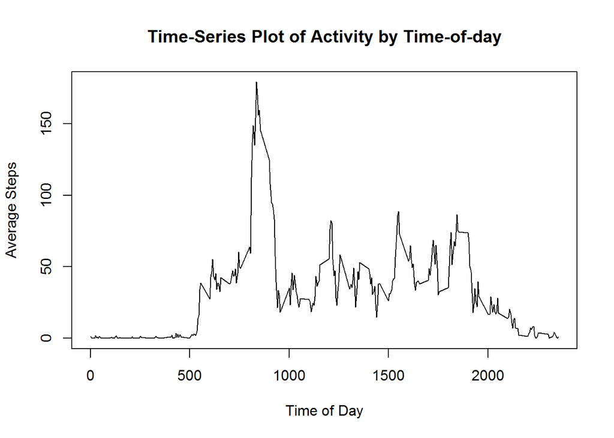

```r
data3<-ddply(data, "interval", function(df)sum(df$steps, na.rm=T))

plot(data3$interval, (data3$V1)/61, type="l", main="Time-Series Plot of Activity by Time-of-day", xlab="Time of Day", ylab="Average Steps")
```

```r
maxsteps<-max(data3$V1)/61
maxsteps
```

```
## [1] 179.1311
```

Note that some data is missing values. The number of missing values is reported by the following R code.

```r
sum(is.na(data$steps))
```

```
## [1] 2304
```

Missing values will simply be imputed by the mean number of steps per 5-minute interval, with no discrimination between separate intervals. This should give a more accurate summation of total activity but may lead to introduction of steps where they are unlikely, such as early in the morning. Note that there are 288 different intervals, used in calculating steps per interval. Total summation of steps is divided first by number of days (61) then by number of intervals (288). This average number of steps per period is then assigned to values that were originally NA.

```r
av<-sum(data3$V1)/61/288
av
```

```
## [1] 32.47996
```

```r
data4<-data
data4[is.na(data4)]<-av
```

A new histogram is the created using data from the imputed data frame.

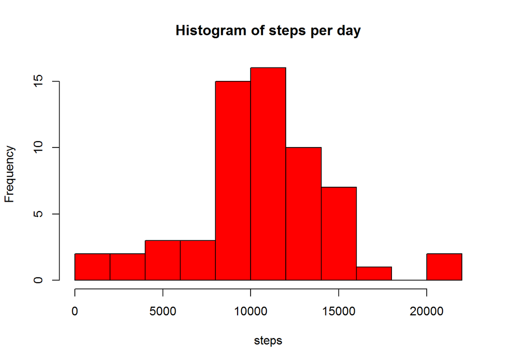

```r
data5<-ddply(data4, "date", function(df)sum(df$steps, na.rm=T))
hist(data5$V1, xlab="steps", col="red", main="Histogram of steps per day", breaks=10)
```

```r
mean(data5$V1, na.rm=T)
```

```
## [1] 10581.01
```

```r
median(data5$V1, na.rm=T)
```

```
## [1] 10395
```

Note that the mean has increased, while the median has remained the same. The total daily number of steps has increased.

The weekdays function is now used on the new data to create a vector of weekdays corresponding to the date in the data.

```r
weekvec<-weekdays(as.Date(data4$date))
for(i in 1:length(weekvec)){
      if (weekvec[i]=="Monday"||weekvec[i]=="Tuesday"||weekvec[i]=="Wednesday"||weekvec[i]=="Thursday"||weekvec[i]=="Friday"
          ) weekvec[i]<-"Weekday"
      else weekvec[i]<-"Weekend"
}
data4<-cbind(data4, weekvec)
head(data4)
```

```
##      steps       date interval weekvec
## 1 32.47996 2012-10-01        0 Weekday
## 2 32.47996 2012-10-01        5 Weekday
## 3 32.47996 2012-10-01       10 Weekday
## 4 32.47996 2012-10-01       15 Weekday
## 5 32.47996 2012-10-01       20 Weekday
## 6 32.47996 2012-10-01       25 Weekday
```